# Análisis Exploratorio de Datos

Crabs Dataset

Escalada Christian

2022-05-20

```r
# Cargamos Librerías:
library(MASS)
data(crabs)

# Preprocesamos Dataset:
crabs$index=NULL
crabs$sex=NULL

# Visualizamos Dataset:
head(crabs)
```

```
##   sp   FL  RW   CL   CW  BD
## 1  B  8.1 6.7 16.1 19.0 7.0
## 2  B  8.8 7.7 18.1 20.8 7.4
## 3  B  9.2 7.8 19.0 22.4 7.7
## 4  B  9.6 7.9 20.1 23.1 8.2
## 5  B  9.8 8.0 20.3 23.0 8.2
## 6  B 10.8 9.0 23.0 26.5 9.8
```

### Dataset crabs de MASS

1. ¿De qué especie son los cangrejos?

```r
?crabs
```

```
## starting httpd help server ... done
```

- Los Cangrejos pertenecen a la especie: *Leptograpsus variegatus*
2. Buscar una imagen de un cangrejo.

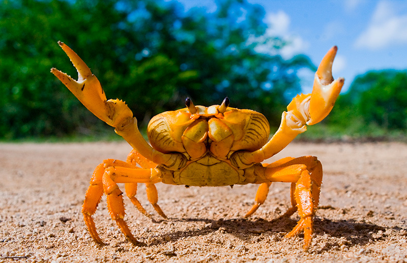

Imagen de cangrejo

### Base de Datos

1. Hacer un `fix(crabs)`.

```r
fix(crabs)
```

2. ¿Cuál es la variable a predecir y cuáles las variables predictoras?

```r
names(crabs)
```

```
## [1] "sp" "FL" "RW" "CL" "CW" "BD"
```

- La Variable a predecir es `sp`.
- Las Variables predictoras son todas las demás.

### Análisis Exploratorio de Datos

1. Hacer un `summary(crabs)` y un `str(crabs)`.

```r
summary(crabs)
```

```
##  sp            FL              RW              CL              CW
##  B:100   Min.   : 7.20   Min.   : 6.50   Min.   :14.70   Min.   :17.10
##  O:100   1st Qu.:12.90   1st Qu.:11.00   1st Qu.:27.27   1st Qu.:31.50
##          Median :15.55   Median :12.80   Median :32.10   Median :36.80
##          Mean   :15.58   Mean   :12.74   Mean   :32.11   Mean   :36.41
##          3rd Qu.:18.05   3rd Qu.:14.30   3rd Qu.:37.23   3rd Qu.:42.00
##          Max.   :23.10   Max.   :20.20   Max.   :47.60   Max.   :54.60
##        BD
##  Min.   : 6.10
##  1st Qu.:11.40
##  Median :13.90
##  Mean   :14.03
##  3rd Qu.:16.60
##  Max.   :21.60
```

```r
str(crabs)
```

```
## 'data.frame':    200 obs. of  6 variables:
##  $ sp: Factor w/ 2 levels "B","O": 1 1 1 1 1 1 1 1 1 1 ...
##  $ FL: num  8.1 8.8 9.2 9.6 9.8 10.8 11.1 11.6 11.8 11.8 ...
##  $ RW: num  6.7 7.7 7.8 7.9 8 9 9.9 9.1 9.6 10.5 ...
##  $ CL: num  16.1 18.1 19 20.1 20.3 23 23.8 24.5 24.2 25.2 ...
##  $ CW: num  19 20.8 22.4 23.1 23 26.5 27.1 28.4 27.8 29.3 ...
##  $ BD: num  7 7.4 7.7 8.2 8.2 9.8 9.8 10.4 9.7 10.3 ...
```

2. ¿Cuántos registros tiene la base? ¿De qué tipo son las variables?
- El Dataset tiene 200 registros, son de tipo categóricas y numéricas.
3. Hacer un `summary(crabs$sp)`

```r
summary(crabs$sp)
```

```
##   B   O
## 100 100
```

4. ¿Cuántos registros por categoría tiene la base?
- El Dataset tiene 100 registros por categoría.

### Gráficos

1. Realizar un Histograma de la variable Largo del caparazón.

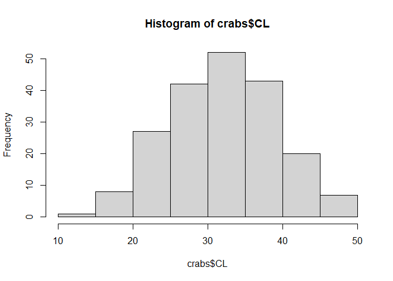

```r
hist(crabs$CL)
```

2. ¿En qué rango se encuentra el largo de los caparazones?

```r
range(crabs$CL)
```

```
## [1] 14.7 47.6
```

- El Largo de los caparazpnes de los cangrejos se encuentran entre: `14.7mm - 47.6mm`.
3. Realizar un histograma cambiando el título y colores del gráfico.

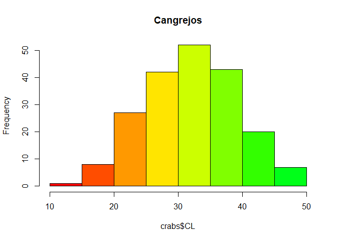

```r
hist(crabs$CL, main="Cangrejos", col=rainbow(20))
```

4. Realizar un Gráfico de Barras de la variable a predecir.

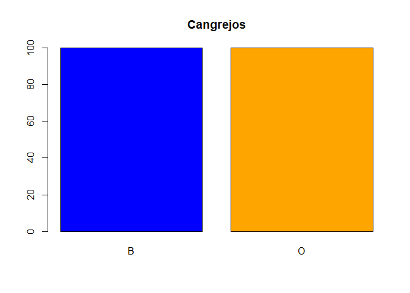

```r
col=c("blue","orange")
plot(crabs$sp, main="Cangrejos", col=col)
```

### Gráficos con la librería caret

1. Realizar un Gráfico de Dispersión de las variables Largo y Ancho de caparazón con caret.

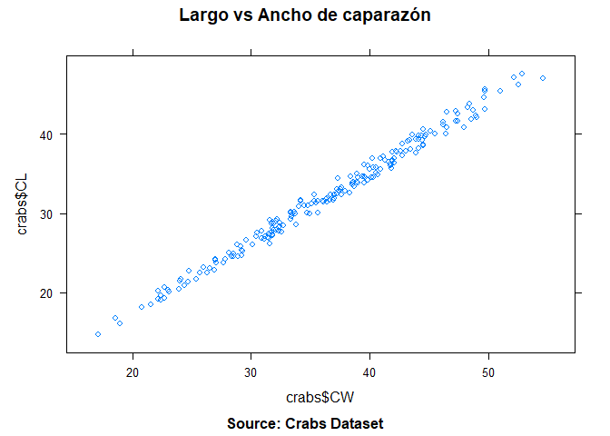

```r
xyplot(crabs$CL~crabs$CW,main="Largo vs Ancho de caparazón",sub="Source: Crabs Dataset",)
```

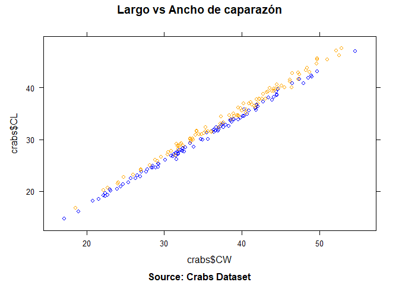

```r
xyplot(crabs$CL~crabs$CW,groups=crabs$sp, col=c("blue","orange"),
       main="Largo vs Ancho de caparazón",sub="Source: Crabs Dataset",)
```

3. Realizar el mismo gráfico pero con pch=19 ¿qué hace eso?

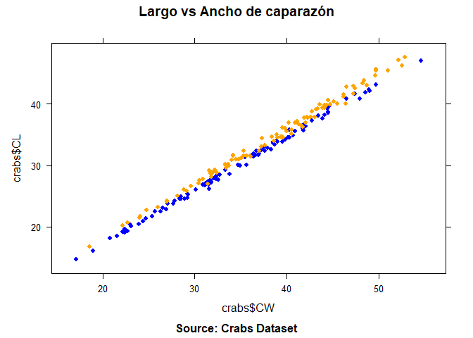

```r
xyplot(crabs$CL~crabs$CW,groups=crabs$sp,pch=19, col=c("blue","orange"),
       main="Largo vs Ancho de caparazón",sub="Source: Crabs Dataset",)
```

4. Probar varios pch numéricos y con por ejemplo pch=“#”.

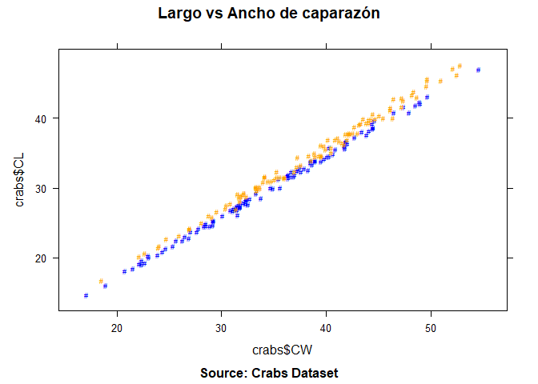

```r
xyplot(crabs$CL~crabs$CW,groups=crabs$sp,pch="#", col=c("blue","orange"),
       main="Largo vs Ancho de caparazón",sub="Source: Crabs Dataset",)
```

5. Agregar la leyenda al gráfico (es decir, qué es cada color) con auto.key

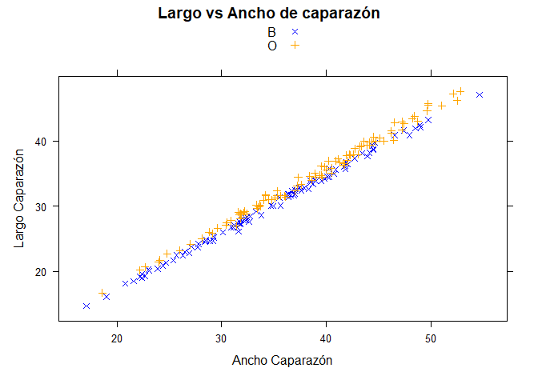

```r
# par.settings te cambia e color y la forma del auto.key

xyplot(crabs$CL~crabs$CW,groups=crabs$sp,pch=c(4,3),auto.key=TRUE,
       par.settings=simpleTheme(col=c("blue","orange"),pch=c(4,3)),
       col=c("blue","orange"),main="Largo vs Ancho de caparazón",
       xlab="Ancho Caparazón", ylab="Largo Caparazón",)
```

### Bibliografía:

1. [RMarkdown básico](http://www.unavarra.es/personal/tgoicoa/ESTADISTICA_RMarkdown_tomas/basicRmarkdown/index.html#14_cuerpo_del_documento)
2. [Introducción al uso de Rmarkdown](https://rpubs.com/tereboca/informe_rmakrdown)
3. [¿Qué es RMarkdown y para qué sirve?](https://bookdown.org/gboccardo/manual-ED-UCH/introduccion-al-uso-de-rmarkdown-para-la-compilacion-de-resultados-de-rstudio-en-diferentes-formatos.html#que-es-rmarkdown-y-para-que-sirve)
4. [Code Chunks](https://rmarkdown.rstudio.com/lesson-3.html)
5. [xyplot pch](http://www.sthda.com/english/wiki/r-plot-pch-symbols-the-different-point-shapes-available-in-r)
6. [par.settings](https://stat.ethz.ch/pipermail/r-help/2009-February/381379.html)

# *Muchas Gracias!!!*

[figure not shown]